# 6 T-tests

Your Name Here

October 05, 2023

Load Packages

```r
#install.packages("openxlsx")

library(foreign)
library(dplyr)
```

```r
library(ggplot2)
library(tidyr)
library(openxlsx)#make sure to install
```

#Set the Working Directory -

```r
setwd("/Users/colinkuehl/Dropbox/POLS 641/2023/Rcode641/Week 5/")#your filepath will be different
getwd()# Checks if correctly set
```

```
## [1] "/Users/colinkuehl/Dropbox/POLS 641/2023/Rcode641/Week 5"
```

Load data: These data are from this 538 story: https://fivethirtyeight.com/features/airplane-etiquette-recline-seat/

The file is in excel format. If we want to we can use a command from the xlsx package(loaded above) to input the data directly.

```r
fly <- readWorkbook("fly.xlsx", sheet="fly", na.strings = "NA")
```

Packages for importing from excel directly can be finicky(due to microsoft updates etc). Thats ok. It is often easier to just click “save as” in the excel program and save your spreadsheet as a csv. When we do this we can use the read.csv command we’ve used in previous classes.

Another note: similar packages exist for important data from STATA, SPSS, SAS, etc.

#Code Book

respondent_id RespondentID gender Gender age Age height Height children_under_18 Do you have any children under 18? household_income Household income bracket education Education Level location Location (census region) frequency How often do you travel by plane? recline_frequency Do you ever recline your seat when you fly? recline_obligation Under normal circumstances, does a person who reclines their seat during a flight have any obligation to the person sitting behind them? recline_rude Is it rude to recline your seat on a plane? recline_eliminate Given the opportunity, would you eliminate the possibility of reclining seats on planes entirely? switch_seats_friends Is it rude to ask someone to switch seats with you in order to be closer to friends? switch_seats_family Is it rude to ask someone to switch seats with you in order to be closer to family wake_up_bathroom Is it rude to wake a passenger up if you are trying to go to the bathroom? wake_up_walk Is it rude to wake a passenger up if you are trying to walk around? baby In general, is it rude to bring a baby on a plane? unruly_child In general, is it rude to knowingly bring unruly children on a plane? two_arm_rests In a row of three seats, who should get to use the two arm rests? middle_arm_rest In a row of two seats, who should get to use the middle arm rest? shade Who should have control over the window shade? unsold_seat Is it rude to move to an unsold seat on a plane? talk_stranger Generally speaking, is it rude to say more than a few words to the stranger sitting next to you on a plane? get_up On a 6 hour flight from NYC to LA, how many times is it acceptable to get up if you’re not in an aisle seat? electronics Have you ever used personal electronics during take off or landing in violation of a flight attendant’s direction? smoked Have you ever smoked a cigarette in an airplane bathroom when it was against the rules?

Getting a feel for the data

```r
names(fly)
```

```
##  [1] "X.1"                  "X"                    "respondent_id"
##  [4] "gender"               "age"                  "height"
##  [7] "children_under_18"    "household_income"     "education"
## [10] "location"             "frequency"            "recline_frequency"
## [13] "recline_obligation"   "recline_rude"         "recline_eliminate"
## [16] "switch_seats_friends" "switch_seats_family"  "wake_up_bathroom"
## [19] "wake_up_walk"         "baby"                 "unruly_child"
## [22] "two_arm_rests"        "middle_arm_rest"      "shade"
## [25] "unsold_seat"          "talk_stranger"        "get_up"
## [28] "electronics"          "smoked"
```

```r
summary(fly)
```

```
##       X.1               X          respondent_id          gender
##  Min.   :   1.0   Min.   :   1.0   Min.   :3.432e+09   Length:1040
##  1st Qu.: 260.8   1st Qu.: 260.8   1st Qu.:3.432e+09   Class :character
##  Median : 520.5   Median : 520.5   Median :3.433e+09   Mode  :character
##  Mean   : 520.5   Mean   : 520.5   Mean   :3.433e+09
##  3rd Qu.: 780.2   3rd Qu.: 780.2   3rd Qu.:3.433e+09
##  Max.   :1040.0   Max.   :1040.0   Max.   :3.436e+09
##      age               height          children_under_18 household_income
##  Length:1040        Length:1040        Mode :logical     Length:1040
##  Class :character   Class :character   FALSE:662         Class :character
##  Mode  :character   Mode  :character   TRUE :189         Mode  :character
##                                        NA's :189
##
##
##   education           location          frequency         recline_frequency
##  Length:1040        Length:1040        Length:1040        Length:1040
##  Class :character   Class :character   Class :character   Class :character
##  Mode  :character   Mode  :character   Mode  :character   Mode  :character
##
##
##
##  recline_obligation recline_rude       recline_eliminate switch_seats_friends
##  Mode :logical      Length:1040        Mode :logical     Length:1040
##  FALSE:311          Class :character   FALSE:595         Class :character
##  TRUE :543          Mode  :character   TRUE :259         Mode  :character
##  NA's :186                             NA's :186
##
##
##  switch_seats_family wake_up_bathroom   wake_up_walk           baby
##  Length:1040         Length:1040        Length:1040        Length:1040
##  Class :character    Class :character   Class :character   Class :character
##  Mode  :character    Mode  :character   Mode  :character   Mode  :character
##
##
##
##  unruly_child       two_arm_rests      middle_arm_rest       shade
##  Length:1040        Length:1040        Length:1040        Length:1040
##  Class :character   Class :character   Class :character   Class :character
##  Mode  :character   Mode  :character   Mode  :character   Mode  :character
##
##
##
##  unsold_seat        talk_stranger         get_up          electronics
##  Length:1040        Length:1040        Length:1040        Mode :logical
##  Class :character   Class :character   Class :character   FALSE:713
##  Mode  :character   Mode  :character   Mode  :character   TRUE :136
##                                                           NA's :191
##
##
##    smoked
##  Mode :logical
##  FALSE:842
##  TRUE :7
##  NA's :191
##
##
```

One of the things you may noticed is the number NA responses

```r
#Often I want know about/ or get rid of respondents with a number of NAs
fly$NAcount <- rowSums(is.na(fly)) #count the number of NAs in each row
summary(fly$NAcount)
```

```
##    Min. 1st Qu.  Median    Mean 3rd Qu.    Max.
##   0.000   0.000   0.000   4.056   1.000  25.000
```

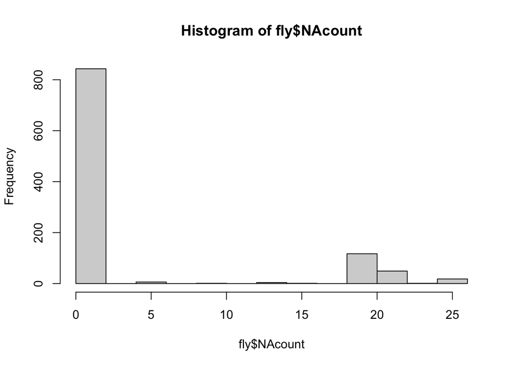

```r
hist(fly$NAcount)
```

```r
#To look at the number of NA responses for a specific variable
sum(is.na(fly$age))
```

```
## [1] 33
```

```r
is.na(fly$age)
```

[output not shown]

[output cut: 72 more lines]

```r
#Dplyr code to get NAs for each variable
fly %>%
  select(everything()) %>%  # replace to your needs
  summarise_all(funs(sum(is.na(.))))
```

```
##   X.1 X respondent_id gender age height children_under_18 household_income
## 1   0 0             0     33  33    182               189              329
##   education location frequency recline_frequency recline_obligation
## 1        39       42         0               182                186
##   recline_rude recline_eliminate switch_seats_friends switch_seats_family
## 1          186               186                  190                 190
##   wake_up_bathroom wake_up_walk baby unruly_child two_arm_rests middle_arm_rest
## 1              190          190  191          191           184             184
##   shade unsold_seat talk_stranger get_up electronics smoked NAcount
## 1   184         185           185    185         191    191       0
```

```r
table(fly$recline_rude)
```

```
##
##       No Somewhat     Very
##      502      281       71
```

```r
str(fly)
```

```
## 'data.frame':    1040 obs. of  30 variables:
##  $ X.1                 : num  1 2 3 4 5 6 7 8 9 10 ...
##  $ X                   : num  1 2 3 4 5 6 7 8 9 10 ...
##  $ respondent_id       : num  3.44e+09 3.43e+09 3.43e+09 3.43e+09 3.43e+09 ...
##  $ gender              : chr  NA "Male" "Male" "Male" ...
##  $ age                 : chr  NA "30-44" "30-44" "30-44" ...
##  $ height              : chr  NA "6'3\"" "5'8\"" "5'11\"" ...
##  $ children_under_18   : logi  NA TRUE FALSE FALSE FALSE TRUE ...
##  $ household_income    : chr  NA NA "$100,000 - $149,999" "$0 - $24,999" ...
##  $ education           : chr  NA "Graduate degree" "Bachelor degree" "Bachelor degree" ...
##  $ location            : chr  NA "Pacific" "Pacific" "Pacific" ...
##  $ frequency           : chr  "Once a year or less" "Once a year or less" "Once a year or less" "Once a year or less" ...
##  $ recline_frequency   : chr  NA "About half the time" "Usually" "Always" ...
##  $ recline_obligation  : logi  NA TRUE TRUE FALSE FALSE TRUE ...
##  $ recline_rude        : chr  NA "Somewhat" "No" "No" ...
```

[output cut: 16 more lines]

```r
is.numeric(fly$recline_rude)
```

```
## [1] FALSE
```

```r
is.factor(fly$recline_rude)
```

```
## [1] FALSE
```

```r
is.character(fly$recline_rude)
```

```
## [1] TRUE
```

Technically, these would be considered ordinal variables, but for our purposes we can treat them as numeric. Thus, we need R to convert them to numeric

```r
fly$nrecline_rude <- as.numeric(as.factor(fly$recline_rude)) #as.numeric(as.factor) converts, but can be tricky. Be sure you check the order makes sense

#much safer to do it this way
fly$nrecline_rude <- recode(fly$recline_rude, "No"=1,"Somewhat"=2, "Very"=3)

table(fly$nrecline_rude)
```

```
##
##   1   2   3
## 502 281  71
```

```r
table(fly$recline_rude)
```

```
##
##       No Somewhat     Very
##      502      281       71
```

```r
prop.table(table(fly$recline_rude))
```

```
##
##         No   Somewhat       Very
## 0.58782201 0.32903981 0.08313817
```

```r
prop.table(table(fly$nrecline_rude))
```

```
##
##          1          2          3
## 0.58782201 0.32903981 0.08313817
```

```r
#always a good idea to confirm values match up. For example this wouldn't work if we tried to recode height the same way
table(fly$age)
```

```
##
##  > 60 18-29 30-44 45-60
##   258   220   254   275
```

```r
fly$agen <- recode(fly$age, "18-29"=1,"30-44"=2, "45-60"=3, "> 60"=4 )
#In this case you can use nested ifelse commands or dplyr's recode.
table(fly$age)
```

```
##
##  > 60 18-29 30-44 45-60
##   258   220   254   275
```

```r
table(fly$agen)
```

```
##
##   1   2   3   4
## 220 254 275 258
```

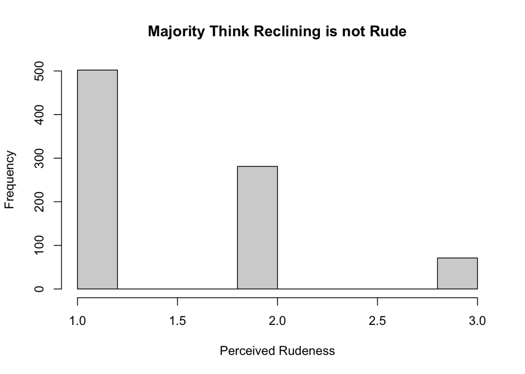

```r
hist(fly$nrecline_rude, main="Majority Think Reclining is not Rude", xlab="Perceived Rudeness")
```

```r
fly$ngender <- recode(fly$gender, "Female"=0, "Male"=1)

table(fly$ngender)
```

```
##
##   0   1
## 528 479
```

```r
table(fly$gender)
```

```
##
## Female   Male
##    528    479
```

Convert a second variable to numeric

```r
fly$nrecline_frequency<- recode(fly$recline_frequency, "Never"=0, "Once in a while"=1, "About half the time"=2, "Usually"=3, "Always"=4)

table(fly$nrecline_frequency)
```

```
##
##   0   1   2   3   4
## 171 257 118 175 137
```

```r
table(fly$recline_frequency)
```

```
##
## About half the time              Always               Never     Once in a while
##                 118                 137                 171                 257
##             Usually
##                 175
```

Using ifelse to recode variables

```r
#sometimes we want to change labels or collapse categories - ie make frequency binary
fly$frequentfliers <- ifelse(fly$frequency=="A few times per month"| fly$frequency=="A few times per week"|fly$frequency=="Every day", 1, 0)
table(fly$frequentfliers) #recall | means or
```

```
##
##    0    1
## 1004   36
```

```r
table(fly$frequency)
```

```
##
## A few times per month  A few times per week             Every day
##                    29                     4                     3
##                 Never  Once a month or less   Once a year or less
##                   166                   205                   633
```

We’ve done some work to make this dataset workable.

We can then export this to a variety of format: (http://www.statmethods.net/input/exportingdata.html)

```r
write.csv(fly, "flyedited.csv") #This will automatically save to your working directory
```

We might think there are differences in attidues between males and females. First we can look at quick crosstabs

```r
crosstab <- table(fly$nrecline_rude, fly$gender)
crosstab
```

```
##
##     Female Male
##   1    258  236
##   2    150  129
##   3     34   36
```

```r
crosstab2 <- prop.table(crosstab, 2) #look at percentage differences between genders. The "2" indicates that the column percentage sums to 1. More info here: https://www.statmethods.net/stats/frequencies.html
crosstab2
```

```
##
##         Female       Male
##   1 0.58371041 0.58852868
##   2 0.33936652 0.32169576
##   3 0.07692308 0.08977556
```

```r
crosstab1 <- prop.table(crosstab, 1)
crosstab1
```

```
##
##        Female      Male
##   1 0.5222672 0.4777328
##   2 0.5376344 0.4623656
##   3 0.4857143 0.5142857
```

```r
#Triple Cross-Tab
crosstab3 <- table(fly$recline_rude, fly$gender, fly$edu)
crosstab3
```

```
## , ,  = Bachelor degree
##
##
##            Female Male
##   No           80   93
##   Somewhat     42   46
##   Very          5   13
##
## , ,  = Graduate degree
##
##
##            Female Male
##   No           85   63
##   Somewhat     47   41
##   Very         17   12
##
## , ,  = High school degree
##
##
##            Female Male
##   No           21    8
##   Somewhat     18   10
##   Very          4    0
##
## , ,  = Less than high school degree
##
##
##            Female Male
##   No            1    0
##   Somewhat      0    3
##   Very          0    2
##
## , ,  = Some college or Associate degree
##
##
##            Female Male
##   No           70   70
##   Somewhat     43   28
##   Very          7    8
```

```r
prop.table(crosstab3)#All cells add up to 1
```

```
## , ,  = Bachelor degree
##
##
##                 Female        Male
##   No       0.095579450 0.111111111
##   Somewhat 0.050179211 0.054958184
##   Very     0.005973716 0.015531661
##
## , ,  = Graduate degree
##
##
##                 Female        Male
##   No       0.101553166 0.075268817
##   Somewhat 0.056152927 0.048984468
##   Very     0.020310633 0.014336918
##
## , ,  = High school degree
##
##
##                 Female        Male
##   No       0.025089606 0.009557945
##   Somewhat 0.021505376 0.011947431
##   Very     0.004778973 0.000000000
##
## , ,  = Less than high school degree
##
##
##                 Female        Male
##   No       0.001194743 0.000000000
##   Somewhat 0.000000000 0.003584229
##   Very     0.000000000 0.002389486
##
## , ,  = Some college or Associate degree
##
##
##                 Female        Male
##   No       0.083632019 0.083632019
##   Somewhat 0.051373955 0.033452808
##   Very     0.008363202 0.009557945
```

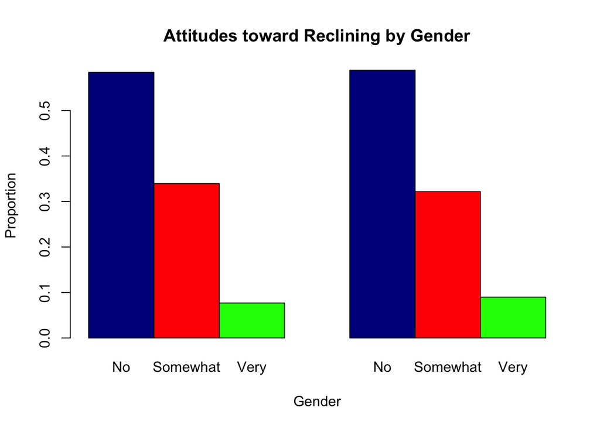

```r
barplot(crosstab2, main="Attitudes toward Reclining by Gender",ylab="Proportion",
  xlab="Gender", col=c("darkblue","red", "green"),beside = TRUE, names.arg = c("No", "Somewhat", "Very","No", "Somewhat", "Very"))
```

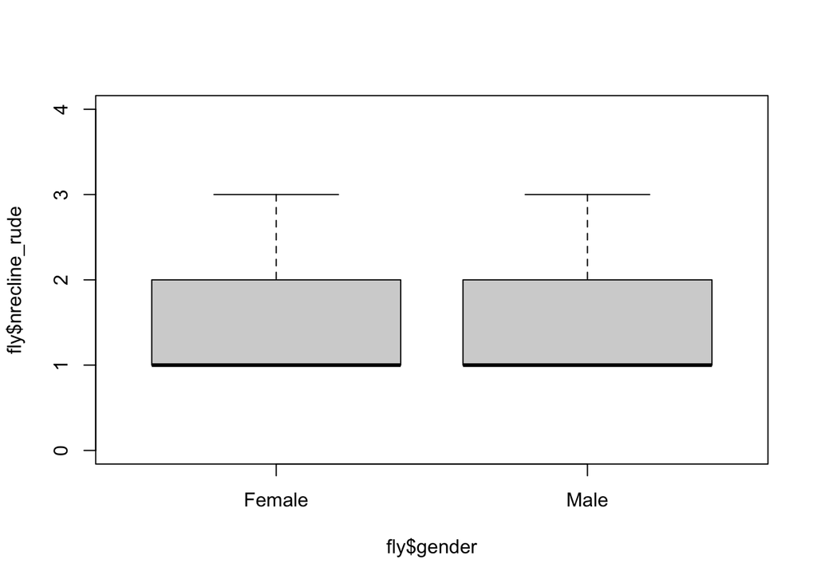

```r
#Show using boxplot
boxplot(fly$nrecline_rude~fly$gender, ylim=c(0,4))
```

Do a t-test to see if this relationship is statisticalsignificant. ie is there a meaningful(statistically significant) difference between men and women’s attitudes toward the rudeness of reclining your airplane seat? ie are they from the same population or different?

```r
t.test(fly$nrecline_rude~ fly$gender) # t= t-statistic, df= degrees of freedom, p-value= only significant (usually) if less than .05, and confidence interval
```

```
##
##  Welch Two Sample t-test
##
## data:  fly$nrecline_rude by fly$gender
## t = -0.18012, df = 827.35, p-value = 0.8571
## alternative hypothesis: true difference in means between group Female and group Male is not equal to 0
## 95 percent confidence interval:
##  -0.09558460  0.07951618
## sample estimates:
## mean in group Female   mean in group Male
##             1.493213             1.501247
```

There are a number of options with the t-test: t.test(x, y = NULL, alternative = c(“two.sided”, “less”, “greater”), mu = 0, paired = FALSE, var.equal = FALSE, conf.level = 0.95)

As a bit of foreshadowing, we can run the same two variables in a bivariate regression and get the same p-value.

```r
summary(lm(nrecline_rude~gender, data=fly))
```

```
##
## Call:
## lm(formula = nrecline_rude ~ gender, data = fly)
##
## Residuals:
##     Min      1Q  Median      3Q     Max
## -0.5012 -0.5012 -0.4932  0.5068  1.5068
##
## Coefficients:
##             Estimate Std. Error t value Pr(>|t|)
## (Intercept) 1.493213   0.030717   48.61   <2e-16 ***
## genderMale  0.008034   0.044537    0.18    0.857
## ---
## Signif. codes:  0 '***' 0.001 '**' 0.01 '*' 0.05 '.' 0.1 ' ' 1
##
## Residual standard error: 0.6458 on 841 degrees of freedom
##   (197 observations deleted due to missingness)
## Multiple R-squared:  3.869e-05,  Adjusted R-squared:  -0.00115
## F-statistic: 0.03254 on 1 and 841 DF,  p-value: 0.8569
```

Try to show this visually

```r
#use dplyr
rude <- fly %>% drop_na(gender)%>% group_by(gender) %>% summarise (me = mean(nrecline_rude, na.rm=T), se=sd(nrecline_rude, na.rm=T)/sqrt(length(nrecline_rude)))
rude #Recall, %>% is called piping. It is a way to add together code. So here I'm saying in the dataset fly, group by gender, and then calculate(summarise) by finding the mean and standard error and put all that in a new dataframe called rude
```

```
## # A tibble: 2 × 3
##   gender    me     se
##   <chr>  <dbl>  <dbl>
## 1 Female  1.49 0.0277
## 2 Male    1.50 0.0300
```

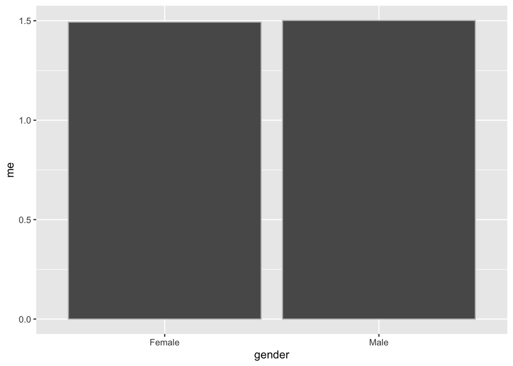

```r
p <-ggplot(aes(x=gender, y=me), data=rude, colour="blue") + geom_bar(stat="identity", colour="grey")
 p
```

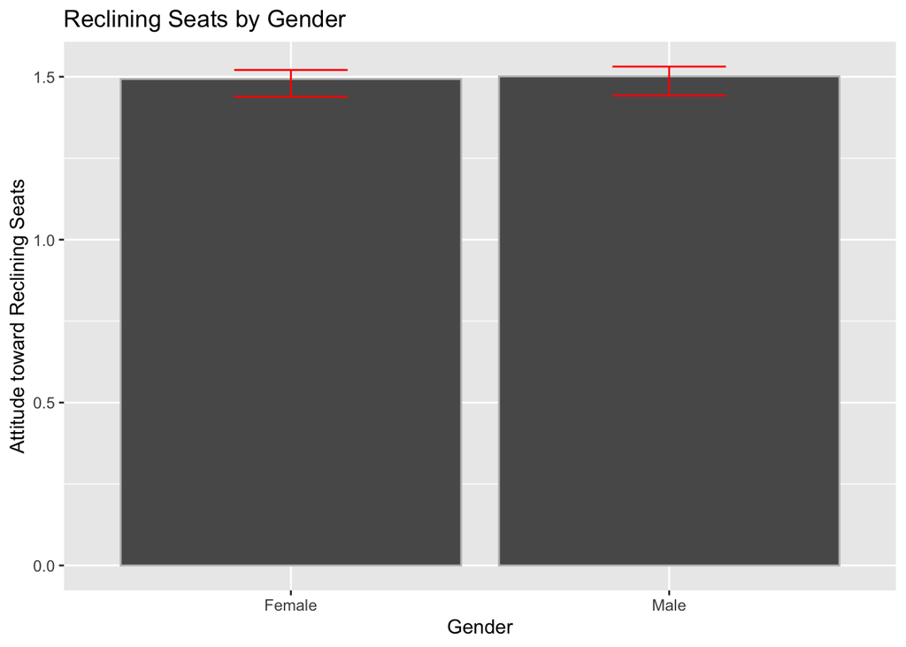

```r
 p+geom_errorbar(aes(ymin=me-(1.96*se), ymax=me+se),
                  colour="red", width=.3) +
 labs(x = "Gender", y = "Attitude toward Reclining Seats") +
  ggtitle("Reclining Seats by Gender")
```

What about differences by education?

Create a new binary variable

```r
table(fly$education) #Look at variable
```

```
##
##                  Bachelor degree                  Graduate degree
##                              325                              284
##               High school degree     Less than high school degree
##                               98                                8
## Some college or Associate degree
##                              286
```

```r
fly$edu <- ifelse(fly$education=="High school degree"|fly$education=="Less than high school degree", 0, 1) #creates a dummy (0, 1)
##more advanced use of ifelse creates categorical variable

table(fly$edu) #alway check to make sure.
```

```
##
##   0   1
## 106 895
```

```r
t.test(fly$nrecline_rude~ fly$edu)
```

```
##
##  Welch Two Sample t-test
##
## data:  fly$nrecline_rude by fly$edu
## t = 1.9499, df = 77.817, p-value = 0.05479
## alternative hypothesis: true difference in means between group 0 and group 1 is not equal to 0
## 95 percent confidence interval:
##  -0.003368177  0.323313903
## sample estimates:
## mean in group 0 mean in group 1
##        1.641791        1.481818
```

Significant at .10, but not .05

#Challenge:

Find a statistically significant difference

Create a new binary variable and look at a different dependent variable(you may need to convert it to numeric)

```r
#playing with other variables
fly$getupn <- recode(fly$get_up, "It is not okay to get up during flight"=0, "Once"=1,"Twice"=2, "Three times"=3, "Four times"=4, "More than five times times"=5)
table(fly$get_up)
```

```
##
##                             Four times It is not okay to get up during flight
##                                    111                                     13
##             More than five times times                                   Once
##                                     91                                     67
##                            Three times                                  Twice
##                                    296                                    277
```

```r
table(fly$getupn)
```

```
##
##   0   1   2   3   4   5
##  13  67 277 296 111  91
```

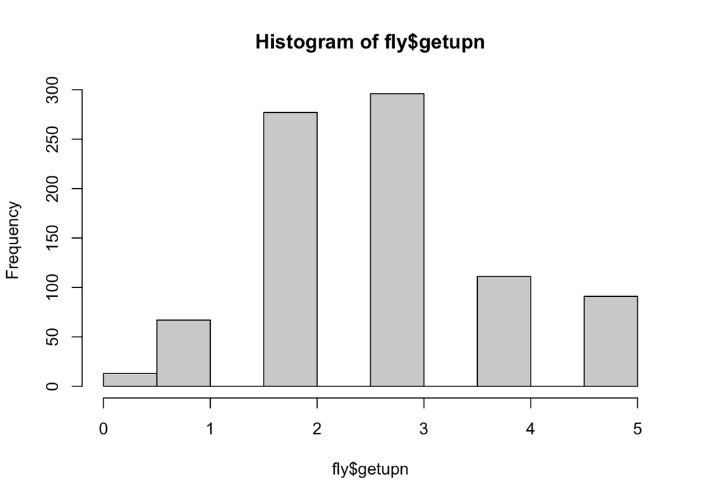

```r
hist(fly$getupn)
```

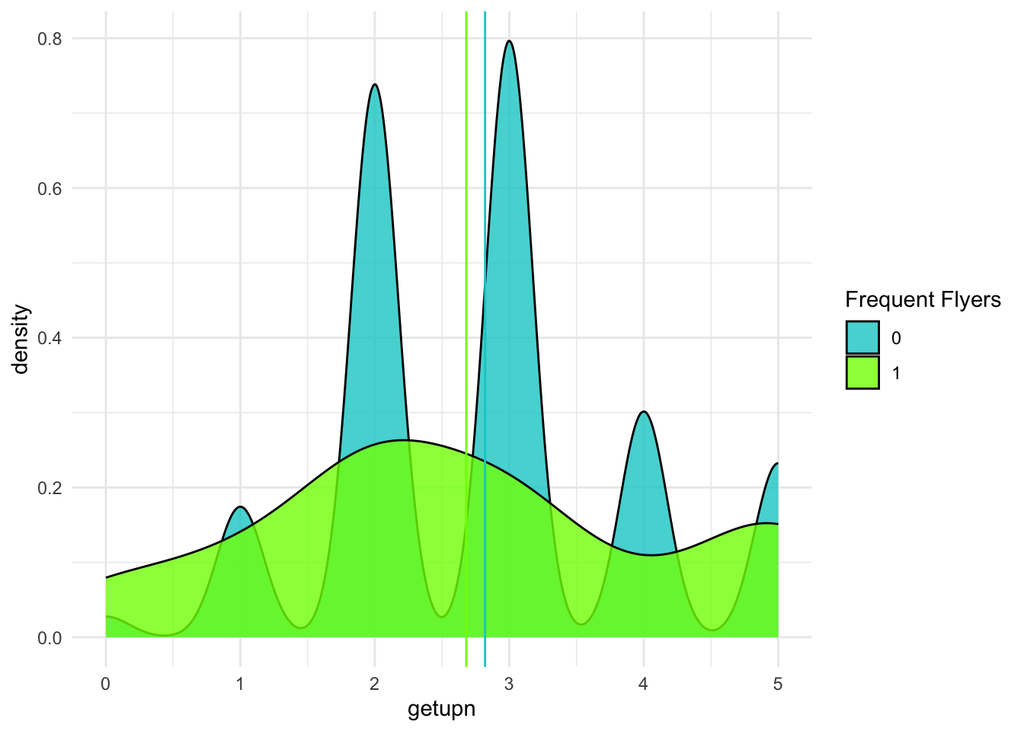

```r
fregm <- fly %>% group_by(frequentfliers)%>% summarise(mean=mean(getupn, na.rm=T))

fly %>% ggplot(aes(x=getupn, fill=as.factor(frequentfliers)))+ geom_density(alpha=.8)+theme_minimal()+scale_fill_manual(values = c("cyan3", "lawngreen"), name="Frequent Flyers")+geom_vline(xintercept=2.82, color="cyan3")+geom_vline(xintercept=2.68, color="lawngreen")
```

```r
t.test(fly$getupn~fly$edu)
```

```
##
##  Welch Two Sample t-test
##
## data:  fly$getupn by fly$edu
## t = -1.4311, df = 85.343, p-value = 0.1561
## alternative hypothesis: true difference in means between group 0 and group 1 is not equal to 0
## 95 percent confidence interval:
##  -0.40597491  0.06614161
## sample estimates:
## mean in group 0 mean in group 1
##        2.671642        2.841558
```

```r
t.test(fly$nrecline_rude~fly$edu)
```

```
##
##  Welch Two Sample t-test
##
## data:  fly$nrecline_rude by fly$edu
## t = 1.9499, df = 77.817, p-value = 0.05479
## alternative hypothesis: true difference in means between group 0 and group 1 is not equal to 0
## 95 percent confidence interval:
##  -0.003368177  0.323313903
## sample estimates:
## mean in group 0 mean in group 1
##        1.641791        1.481818
```